# Regression analysis

## Distributions

### Missing values

| variable | n_missing | pct_missing |
| --- | --- | --- |
| EstimatedAgeArrival | 5 | 9.4 |
| InfancySocialExposure | 10 | 18.9 |
| JuvenileSocialExposure | 5 | 9.4 |
| NutritionDep | 25 | 47.2 |
| Others | 1 | 1.9 |
| PhysicalHarm | 22 | 41.5 |
| YearsCenter | 5 | 9.4 |

### Sex and species

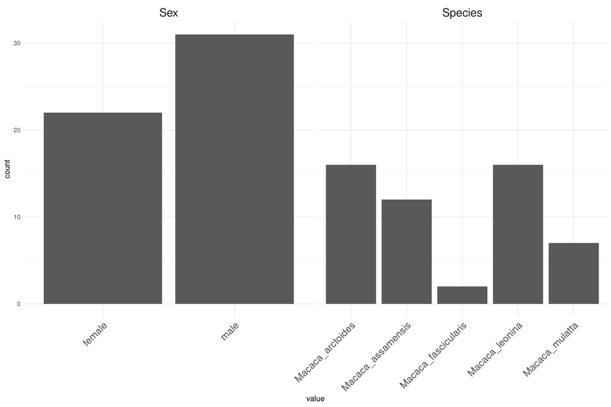

### Adversity

#### Coding schemes

**Threat indicators**

| Variable | Score | Item description |
| --- | --- | --- |
| Life experience | 1 | Zoo (born in the former zoo and spent their life in captivity) |
|  | 2 | Trade (rescued from poaching) |
|  | 3 | Pet (chains, cages, etc) |
|  | 3 | Entertainment (being caged in resorts, temples, etc) |
| Physical harm | 1 | No physical harm |
|  | 2 | Indirect (mobility restriction, chains, cage..) |
|  | 3 | Direct (beats, scars..) |

**Deprivation indicators**

| Variable | Score | Item description |
| --- | --- | --- |
| Type of rearing | 1 | Parenting (reared by biological parents or surogate mother/father |
|  | 2 | Hand (reared by humans) |
| Infancy social exposure | 1 | Accompanied by peers 80% infancy |
|  | 2 | Mixed or accompanied by peers 80-20% infancy |
|  | 3 | Alone more than 80% infancy |
| Juvenile social exposure | 1 | Accompanied by peers 80% juvenility |
|  | 2 | Mixed or accompanied by peers 80-20% juvenility |
|  | 3 | Alone more than 80% juvenility |
| Nutrition deprivation | 1 | Balanced (mostly balanced during life, adequate food items) |
|  | 2 | Unbalanced (poor, harmful foods like soda or snacks…) |
| Mother separation | 1 | No |
|  | 2 | Yes |

*NB: Mother separation is not used as an unpredictability indicator but a deprivation indicator contrary to what was declared in the preregistration.*

**Unpredictability indicators**

| Variable | Score | Item description |
| --- | --- | --- |
| Number of relocations | 1 | born at the center |
|  | 2 | relocated at least once (to the rescue center) |
|  | 3 | relocated at least twice (usually market + rescue center) |
|  | 4 | relocated more than twice (more than two environments before center) |

#### Distributions of raw variables

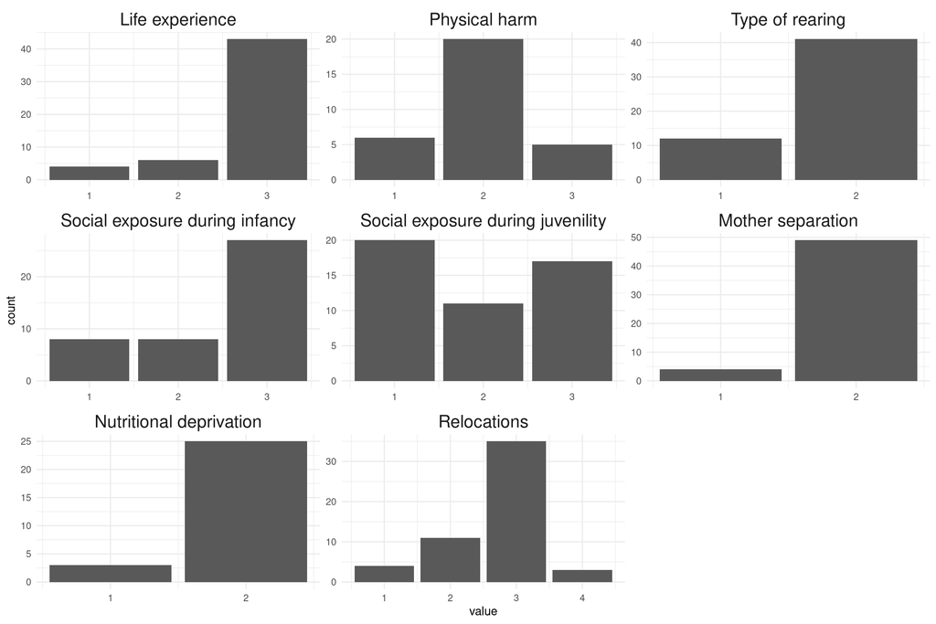

### Psychopathology

The indicators for anxiety, depression and ISS mix behavioural observations with items from the Macaques Social Responsiveness scale. The latter is rated on a 1-5 Likert scale and ratings from 3 observers are averaged. Some items are reversed scored but were already recoded in the original source file `DataRecoded.xslx` sent by Mikel. See [F1000research paper](https://f1000research.com/articles/13-188).

#### Anxiety

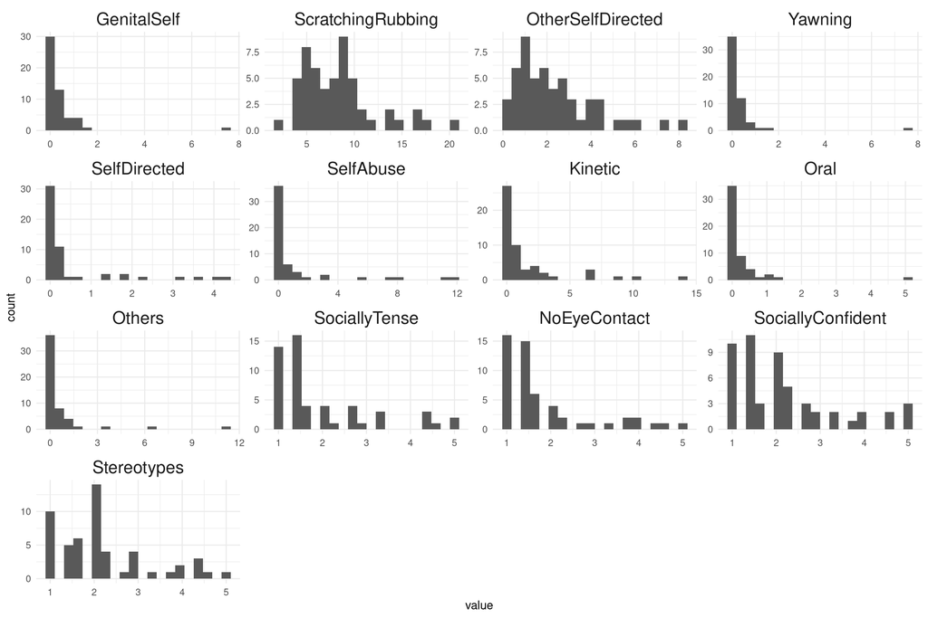

#### Depression

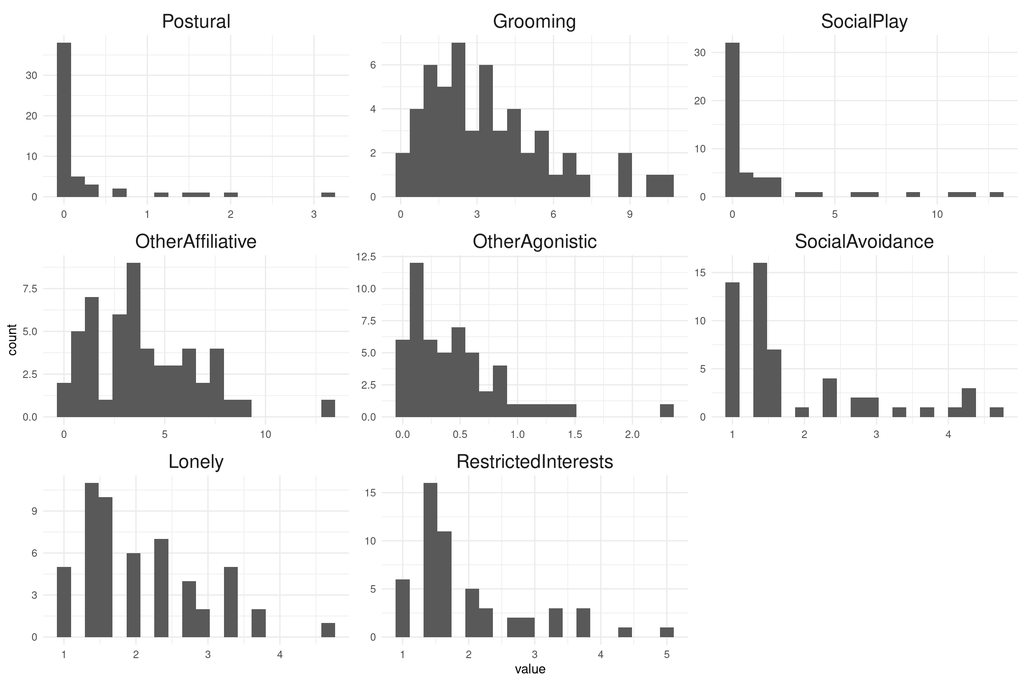

#### ISS

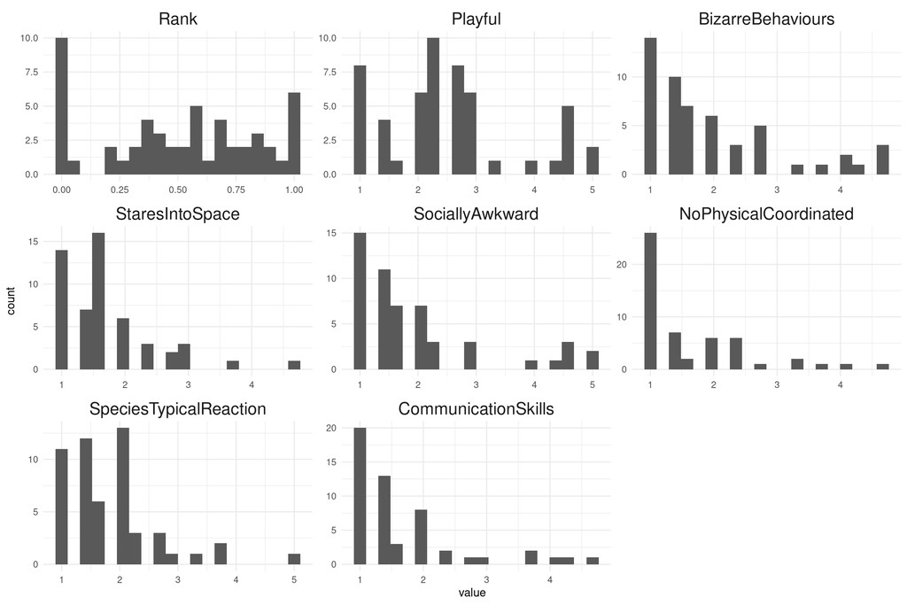

### Estimated age at arrival and Years spent at center

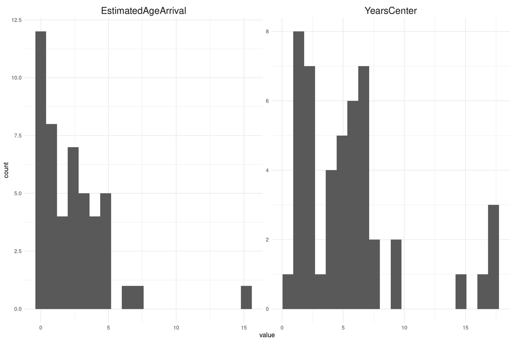

## Distributions of continuous regression variables after imputation

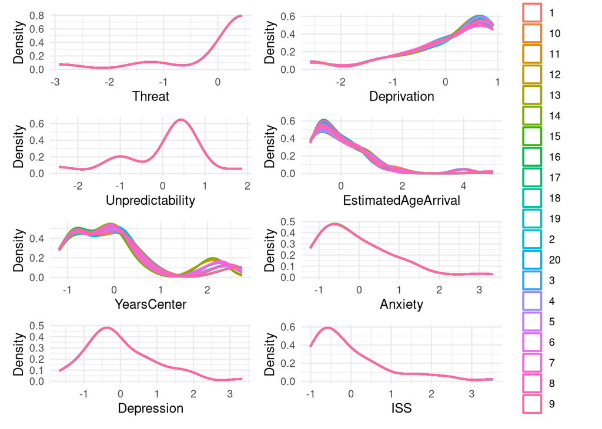

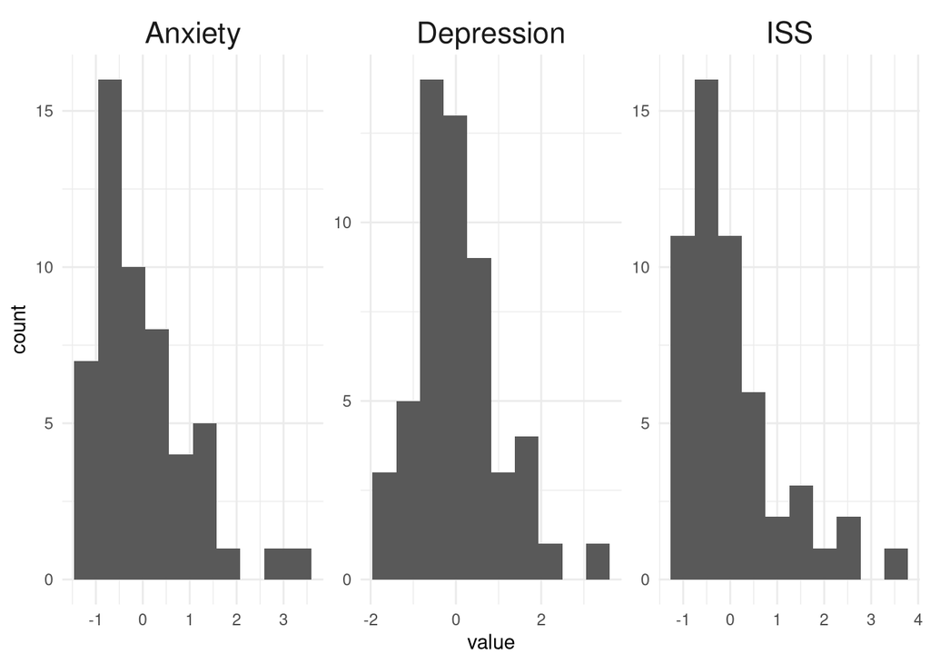

## Correlation plots

### Adversity

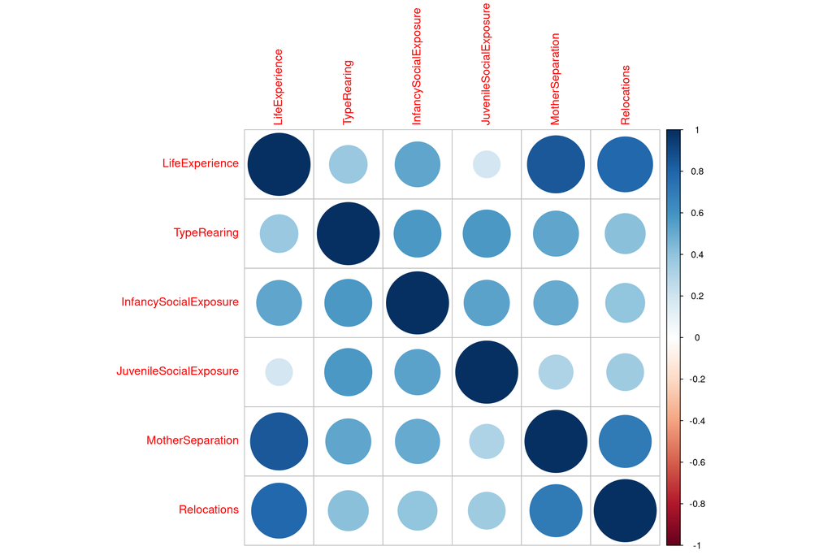

### Pyschopathology

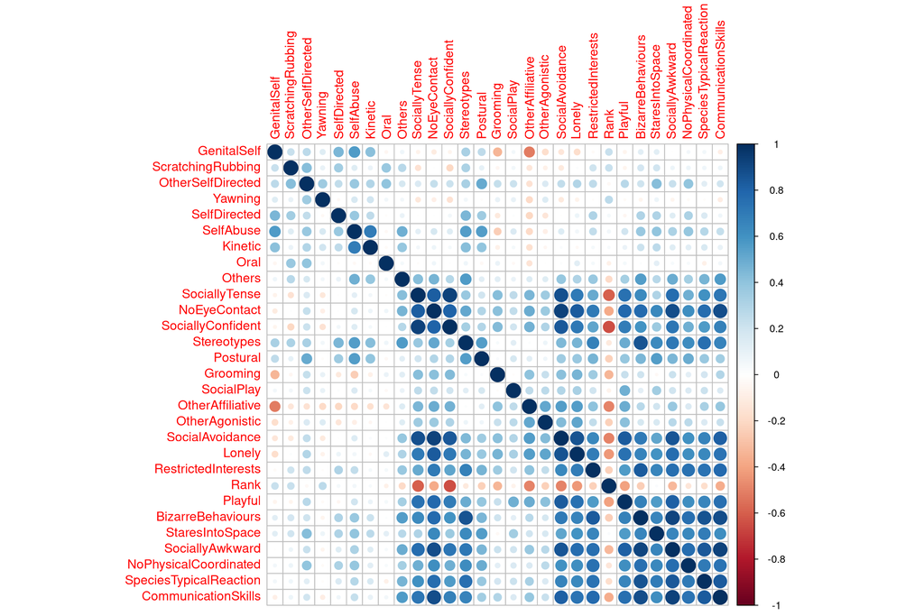

**Cronbach’s alpha:** 0.91

#### Anxiety items

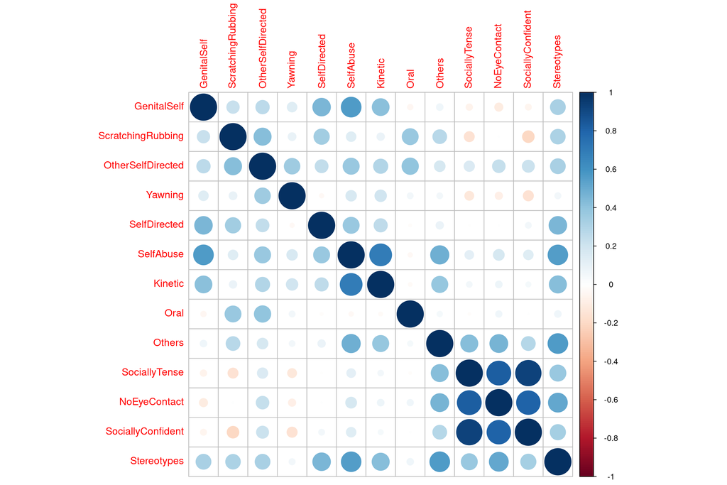

**Cronbach’s alpha** 0.78

#### Depression items

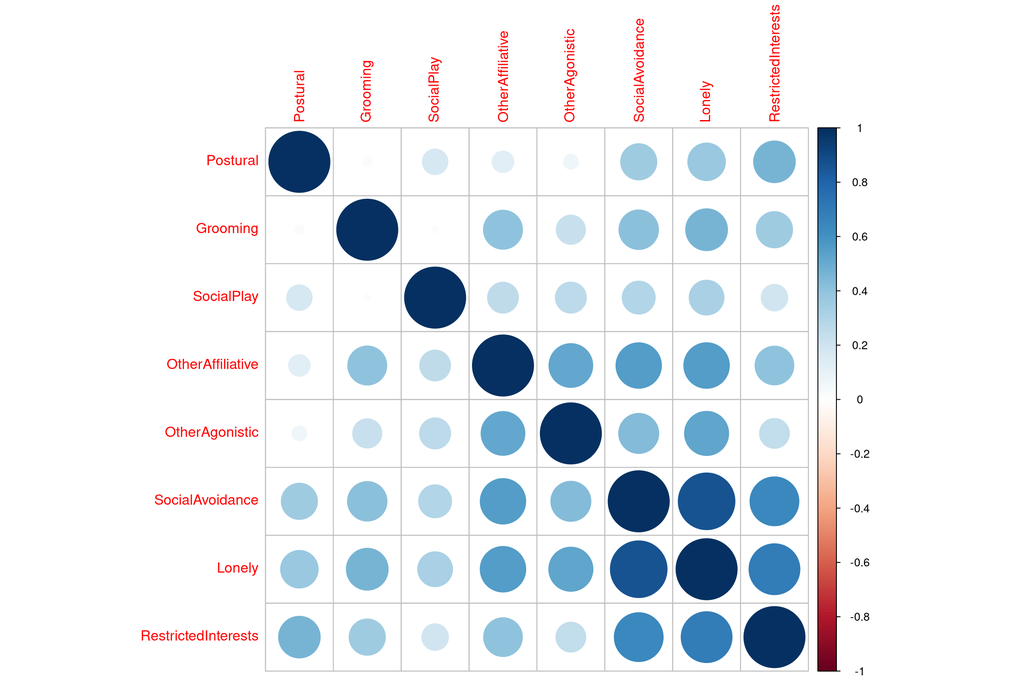

**Cronbach’s alpha** 0.82

#### ISS items

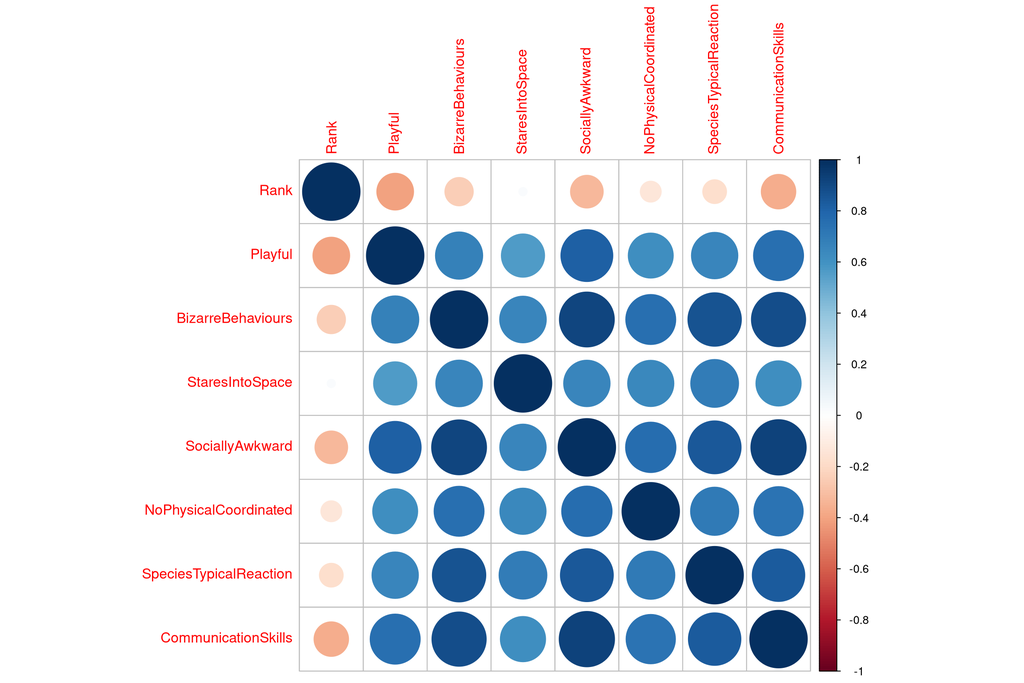

**Cronbach’s alpha** 0.89

#### Model variables (all numeric variables)

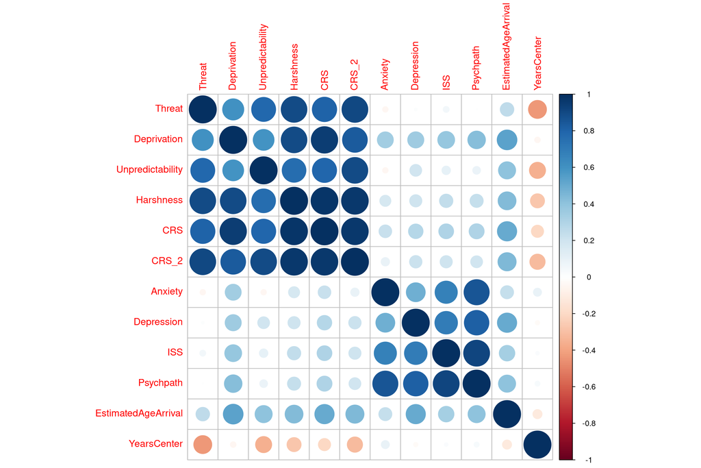

## Regression models

### Summary table for all models (PREDICTORS ONLY)

| Parameter | Posterior Estimate | Posterior **95% CrI** | P(direction) | Convergence Rhat | Convergence Bulk ESS | Convergence Tail ESS |
| --- | --- | --- | --- | --- | --- | --- |
| Model 1A |  |  |  |  |  |  |
| Anxiety ~ Threat | −0.17 | [−0.50, 0.18] | 0.831 | 1.001 | 4,413 | 5,030 |
| Anxiety ~ Deprivation | 0.58 | [0.29, 0.86] | 1.000 | 1.001 | 4,960 | 5,142 |
| Anxiety ~ Unpredictability | −0.21 | [−0.55, 0.13] | 0.885 | 1.001 | 4,481 | 4,817 |
| Depression ~ Threat | −0.39 | [−0.74, −0.03] | 0.982 | 1.002 | 3,912 | 4,984 |
| Depression ~ Deprivation | 0.36 | [0.06, 0.66] | 0.989 | 1.002 | 5,266 | 5,339 |
| Depression ~ Unpredictability | 0.28 | [−0.07, 0.63] | 0.941 | 1.001 | 4,393 | 4,498 |
| ISS ~ Threat | −0.18 | [−0.53, 0.19] | 0.836 | 1.001 | 3,814 | 4,676 |
| ISS ~ Deprivation | 0.47 | [0.16, 0.77] | 0.998 | 1.001 | 4,743 | 5,011 |
| ISS ~ Unpredictability | 0.00 | [−0.35, 0.36] | 0.506 | 1.002 | 4,041 | 4,993 |
| Model 1B |  |  |  |  |  |  |
| Anxiety ~ CRS | 0.14 | [−0.13, 0.40] | 0.851 | 1.001 | 5,092 | 5,461 |
| Depression ~ CRS | 0.18 | [−0.08, 0.44] | 0.917 | 1.001 | 5,468 | 5,220 |
| ISS ~ CRS | 0.21 | [−0.05, 0.47] | 0.947 | 1.001 | 4,700 | 5,345 |
| Model 2A |  |  |  |  |  |  |
| Anxiety ~ Threat | −0.19 | [−0.59, 0.21] | 0.822 | 1.001 | 4,872 | 4,794 |
| Anxiety ~ EstimatedAgeArrival | 0.03 | [−0.37, 0.44] | 0.561 | 1.001 | 5,010 | 4,664 |
| Anxiety ~ Deprivation | 0.53 | [0.10, 0.95] | 0.992 | 1.001 | 4,881 | 5,329 |
| Anxiety ~ Unpredictability | −0.30 | [−0.64, 0.04] | 0.960 | 1.002 | 5,310 | 5,050 |
| Anxiety ~ Threat:EstimatedAgeArrival | −0.27 | [−0.74, 0.21] | 0.868 | 1.001 | 5,628 | 5,211 |
| Anxiety ~ Deprivation:EstimatedAgeArrival | −0.18 | [−0.69, 0.34] | 0.749 | 1.001 | 4,538 | 4,743 |
| Anxiety ~ Unpredictability:EstimatedAgeArrival | 0.36 | [0.05, 0.67] | 0.989 | 1.001 | 5,033 | 5,166 |
| Depression ~ Threat | −0.28 | [−0.70, 0.14] | 0.906 | 1.002 | 5,085 | 5,124 |
| Depression ~ EstimatedAgeArrival | 0.22 | [−0.20, 0.65] | 0.851 | 1.001 | 5,163 | 5,469 |
| Depression ~ Deprivation | 0.31 | [−0.13, 0.75] | 0.916 | 1.001 | 4,954 | 5,186 |
| Depression ~ Unpredictability | 0.16 | [−0.20, 0.51] | 0.811 | 1.001 | 5,789 | 5,589 |
| Depression ~ Threat:EstimatedAgeArrival | −0.02 | [−0.52, 0.47] | 0.539 | 1.001 | 5,340 | 4,739 |
| Depression ~ Deprivation:EstimatedAgeArrival | 0.06 | [−0.46, 0.59] | 0.597 | 1.001 | 5,000 | 4,770 |
| Depression ~ Unpredictability:EstimatedAgeArrival | 0.10 | [−0.21, 0.42] | 0.738 | 1.001 | 5,077 | 5,381 |
| ISS ~ Threat | −0.18 | [−0.60, 0.25] | 0.802 | 1.001 | 5,000 | 5,187 |
| ISS ~ EstimatedAgeArrival | 0.09 | [−0.37, 0.56] | 0.646 | 1.001 | 4,857 | 5,335 |
| ISS ~ Deprivation | 0.43 | [−0.01, 0.87] | 0.973 | 1.001 | 4,785 | 4,996 |
| ISS ~ Unpredictability | −0.06 | [−0.43, 0.31] | 0.625 | 1.001 | 5,600 | 5,586 |
| ISS ~ Threat:EstimatedAgeArrival | −0.17 | [−0.67, 0.33] | 0.748 | 1.001 | 5,386 | 5,358 |
| ISS ~ Deprivation:EstimatedAgeArrival | −0.02 | [−0.61, 0.57] | 0.521 | 1.001 | 4,954 | 5,240 |
| ISS ~ Unpredictability:EstimatedAgeArrival | 0.18 | [−0.20, 0.54] | 0.814 | 1.002 | 5,220 | 4,507 |
| Model 2B |  |  |  |  |  |  |
| Anxiety ~ CRS | −0.02 | [−0.39, 0.35] | 0.542 | 1.001 | 3,714 | 4,975 |
| Anxiety ~ EstimatedAgeArrival | 0.33 | [−0.06, 0.71] | 0.951 | 1.001 | 3,976 | 4,995 |
| Anxiety ~ CRS:EstimatedAgeArrival | −0.07 | [−0.41, 0.27] | 0.665 | 1.001 | 3,512 | 4,284 |
| Depression ~ CRS | 0.11 | [−0.24, 0.46] | 0.732 | 1.002 | 3,745 | 4,763 |
| Depression ~ EstimatedAgeArrival | 0.33 | [−0.03, 0.69] | 0.964 | 1.002 | 3,746 | 5,128 |
| Depression ~ CRS:EstimatedAgeArrival | 0.13 | [−0.18, 0.46] | 0.795 | 1.002 | 3,414 | 5,170 |
| ISS ~ CRS | 0.10 | [−0.27, 0.48] | 0.706 | 1.002 | 3,383 | 4,893 |
| ISS ~ EstimatedAgeArrival | 0.27 | [−0.14, 0.70] | 0.899 | 1.002 | 3,420 | 4,481 |
| ISS ~ CRS:EstimatedAgeArrival | −0.02 | [−0.35, 0.32] | 0.548 | 1.002 | 3,404 | 4,555 |
| Model 3A |  |  |  |  |  |  |
| Anxiety ~ Threat | −0.16 | [−0.54, 0.23] | 0.791 | 1.002 | 5,220 | 5,312 |
| Anxiety ~ YearsCenter | −0.06 | [−0.36, 0.26] | 0.643 | 1.002 | 4,885 | 5,192 |
| Anxiety ~ Deprivation | 0.62 | [0.29, 0.91] | 1.000 | 1.001 | 5,158 | 4,840 |
| Anxiety ~ Unpredictability | −0.27 | [−0.65, 0.12] | 0.914 | 1.001 | 4,697 | 4,953 |
| Anxiety ~ Threat:YearsCenter | 0.20 | [−0.30, 0.83] | 0.758 | 1.002 | 4,675 | 4,958 |
| Anxiety ~ Deprivation:YearsCenter | −0.03 | [−0.38, 0.31] | 0.574 | 1.001 | 5,216 | 5,131 |
| Anxiety ~ Unpredictability:YearsCenter | −0.20 | [−1.01, 0.36] | 0.721 | 1.002 | 4,598 | 4,899 |
| Depression ~ Threat | −0.40 | [−0.80, 0.00] | 0.974 | 1.001 | 4,740 | 5,573 |
| Depression ~ YearsCenter | −0.12 | [−0.45, 0.20] | 0.769 | 1.002 | 5,065 | 5,217 |
| Depression ~ Deprivation | 0.42 | [0.09, 0.73] | 0.993 | 1.001 | 5,350 | 5,625 |
| Depression ~ Unpredictability | 0.26 | [−0.11, 0.63] | 0.917 | 1.001 | 4,760 | 5,168 |
| Depression ~ Threat:YearsCenter | 0.02 | [−0.50, 0.47] | 0.536 | 1.002 | 4,710 | 5,164 |
| Depression ~ Deprivation:YearsCenter | −0.07 | [−0.44, 0.31] | 0.641 | 1.001 | 5,487 | 5,234 |
| Depression ~ Unpredictability:YearsCenter | −0.11 | [−0.60, 0.47] | 0.657 | 1.001 | 4,869 | 5,175 |
| ISS ~ Threat | −0.21 | [−0.60, 0.20] | 0.845 | 1.002 | 4,987 | 4,932 |
| ISS ~ YearsCenter | −0.06 | [−0.46, 0.39] | 0.595 | 1.001 | 5,067 | 5,270 |
| ISS ~ Deprivation | 0.48 | [0.13, 0.81] | 0.996 | 1.001 | 4,980 | 5,226 |
| ISS ~ Unpredictability | 0.01 | [−0.36, 0.40] | 0.530 | 1.002 | 4,601 | 5,140 |
| ISS ~ Threat:YearsCenter | 0.02 | [−0.49, 0.49] | 0.538 | 1.001 | 4,716 | 5,185 |
| ISS ~ Deprivation:YearsCenter | −0.03 | [−0.38, 0.33] | 0.573 | 1.001 | 4,815 | 5,468 |
| ISS ~ Unpredictability:YearsCenter | −0.02 | [−0.52, 0.57] | 0.527 | 1.001 | 4,375 | 5,467 |
| Model 3B |  |  |  |  |  |  |
| Anxiety ~ CRS | 0.17 | [−0.13, 0.45] | 0.871 | 1.002 | 4,750 | 5,137 |
| Anxiety ~ YearsCenter | 0.09 | [−0.20, 0.38] | 0.742 | 1.001 | 5,083 | 5,073 |
| Anxiety ~ CRS:YearsCenter | −0.02 | [−0.31, 0.26] | 0.566 | 1.001 | 4,713 | 4,923 |
| Depression ~ CRS | 0.24 | [−0.04, 0.53] | 0.953 | 1.001 | 4,721 | 4,804 |
| Depression ~ YearsCenter | −0.02 | [−0.31, 0.26] | 0.568 | 1.002 | 4,684 | 4,971 |
| Depression ~ CRS:YearsCenter | −0.17 | [−0.46, 0.11] | 0.883 | 1.002 | 4,411 | 5,167 |
| ISS ~ CRS | 0.24 | [−0.05, 0.52] | 0.951 | 1.001 | 4,168 | 5,162 |
| ISS ~ YearsCenter | 0.05 | [−0.29, 0.43] | 0.589 | 1.003 | 4,492 | 5,431 |
| ISS ~ CRS:YearsCenter | −0.04 | [−0.36, 0.33] | 0.577 | 1.002 | 4,347 | 5,084 |

Estimates are posterior medians or means pooled across imputed datasets; intervals are equal-tailed 95% CrIs.  
P(direction) = probability of direction.  
Convergence diagnostics are the worst values across imputations; shaded cells have Rhat > 1.01 or ESS < 400.

### Summary table for all models (ALL PARAMETERS)

| Parameter | Posterior Estimate | Posterior **95% CrI** | P(direction) | Convergence Rhat | Convergence Bulk ESS | Convergence Tail ESS |
| --- | --- | --- | --- | --- | --- | --- |
| Model 1A |  |  |  |  |  |  |
| Anxiety_Sex_2female | −0.31 | [−0.71, 0.11] | 0.931 | 1.001 | 4,631 | 4,393 |
| Anxiety_Sex_2male | 0.20 | [−0.20, 0.58] | 0.855 | 1.002 | 4,103 | 4,003 |
| Anxiety_Threat | −0.17 | [−0.50, 0.18] | 0.831 | 1.001 | 4,413 | 5,030 |
| Anxiety_Deprivation | 0.58 | [0.29, 0.86] | 1.000 | 1.001 | 4,960 | 5,142 |
| Anxiety_Unpredictability | −0.21 | [−0.55, 0.13] | 0.885 | 1.001 | 4,481 | 4,817 |
| Depression_Sex_2female | 0.18 | [−0.24, 0.58] | 0.809 | 1.001 | 4,839 | 4,608 |
| Depression_Sex_2male | −0.12 | [−0.49, 0.26] | 0.745 | 1.002 | 4,618 | 4,297 |
| Depression_Threat | −0.39 | [−0.74, −0.03] | 0.982 | 1.002 | 3,912 | 4,984 |
| Depression_Deprivation | 0.36 | [0.06, 0.66] | 0.989 | 1.002 | 5,266 | 5,339 |
| Depression_Unpredictability | 0.28 | [−0.07, 0.63] | 0.941 | 1.001 | 4,393 | 4,498 |
| ISS_Sex_2female | −0.03 | [−0.44, 0.38] | 0.562 | 1.002 | 4,645 | 5,150 |
| ISS_Sex_2male | 0.04 | [−0.34, 0.42] | 0.587 | 1.002 | 4,171 | 4,113 |
| ISS_Threat | −0.18 | [−0.53, 0.19] | 0.836 | 1.001 | 3,814 | 4,676 |
| ISS_Deprivation | 0.47 | [0.16, 0.77] | 0.998 | 1.001 | 4,743 | 5,011 |
| ISS_Unpredictability | 0.00 | [−0.35, 0.36] | 0.506 | 1.002 | 4,041 | 4,993 |
| sd_Species_2__Anxiety_Intercept | 0.27 | [0.02, 0.88] |  | 1.002 | 2,222 | 2,083 |
| sd_Species_2__Depression_Intercept | 0.21 | [0.01, 0.80] |  | 1.003 | 2,399 | 2,577 |
| sd_Species_2__ISS_Intercept | 0.22 | [0.01, 0.79] |  | 1.002 | 2,481 | 2,795 |
| sigma_Anxiety | 0.83 | [0.68, 1.03] |  | 1.001 | 5,869 | 5,240 |
| sigma_Depression | 0.88 | [0.73, 1.09] |  | 1.001 | 6,071 | 5,498 |
| sigma_ISS | 0.89 | [0.74, 1.10] |  | 1.001 | 5,540 | 5,347 |
| rescor__Anxiety__Depression | 0.46 | [0.21, 0.65] | 1.000 | 1.001 | 5,312 | 5,500 |
| rescor__Anxiety__ISS | 0.55 | [0.32, 0.72] | 1.000 | 1.001 | 5,198 | 5,580 |
| rescor__Depression__ISS | 0.59 | [0.37, 0.74] | 1.000 | 1.001 | 5,926 | 5,453 |
| Model 1B |  |  |  |  |  |  |
| Anxiety_Sex_2female | −0.22 | [−0.66, 0.23] | 0.839 | 1.001 | 4,324 | 4,684 |
| Anxiety_Sex_2male | 0.15 | [−0.29, 0.57] | 0.760 | 1.001 | 4,063 | 4,693 |
| Anxiety_CRS_2 | 0.14 | [−0.13, 0.40] | 0.851 | 1.001 | 5,092 | 5,461 |
| Depression_Sex_2female | 0.21 | [−0.21, 0.62] | 0.841 | 1.001 | 4,896 | 4,355 |

[output cut: 138 more lines]

Estimates are posterior medians or means pooled across imputed datasets; intervals are equal-tailed 95% CrIs.  
P(direction) = probability of direction.  
Convergence diagnostics are the worst values across imputations; shaded cells have Rhat > 1.01 or ESS < 400.

### Model 1A - Dimensional analysis between early-life adversity predictors and behavioural outcomes

| Parameter | Posterior Estimate | Posterior **95% CrI** | P(direction) | Convergence Rhat | Convergence Bulk ESS | Convergence Tail ESS |
| --- | --- | --- | --- | --- | --- | --- |
| Model 1A |  |  |  |  |  |  |
| Anxiety_Sex_2female | −0.31 | [−0.71, 0.11] | 0.931 | 1.001 | 4,631 | 4,393 |
| Anxiety_Sex_2male | 0.20 | [−0.20, 0.58] | 0.855 | 1.002 | 4,103 | 4,003 |
| Anxiety_Threat | −0.17 | [−0.50, 0.18] | 0.831 | 1.001 | 4,413 | 5,030 |
| Anxiety_Deprivation | 0.58 | [0.29, 0.86] | 1.000 | 1.001 | 4,960 | 5,142 |
| Anxiety_Unpredictability | −0.21 | [−0.55, 0.13] | 0.885 | 1.001 | 4,481 | 4,817 |
| Depression_Sex_2female | 0.18 | [−0.24, 0.58] | 0.809 | 1.001 | 4,839 | 4,608 |
| Depression_Sex_2male | −0.12 | [−0.49, 0.26] | 0.745 | 1.002 | 4,618 | 4,297 |
| Depression_Threat | −0.39 | [−0.74, −0.03] | 0.982 | 1.002 | 3,912 | 4,984 |
| Depression_Deprivation | 0.36 | [0.06, 0.66] | 0.989 | 1.002 | 5,266 | 5,339 |
| Depression_Unpredictability | 0.28 | [−0.07, 0.63] | 0.941 | 1.001 | 4,393 | 4,498 |
| ISS_Sex_2female | −0.03 | [−0.44, 0.38] | 0.562 | 1.002 | 4,645 | 5,150 |
| ISS_Sex_2male | 0.04 | [−0.34, 0.42] | 0.587 | 1.002 | 4,171 | 4,113 |
| ISS_Threat | −0.18 | [−0.53, 0.19] | 0.836 | 1.001 | 3,814 | 4,676 |
| ISS_Deprivation | 0.47 | [0.16, 0.77] | 0.998 | 1.001 | 4,743 | 5,011 |
| ISS_Unpredictability | 0.00 | [−0.35, 0.36] | 0.506 | 1.002 | 4,041 | 4,993 |
| sd_Species_2__Anxiety_Intercept | 0.27 | [0.02, 0.88] |  | 1.002 | 2,222 | 2,083 |
| sd_Species_2__Depression_Intercept | 0.21 | [0.01, 0.80] |  | 1.003 | 2,399 | 2,577 |
| sd_Species_2__ISS_Intercept | 0.22 | [0.01, 0.79] |  | 1.002 | 2,481 | 2,795 |
| sigma_Anxiety | 0.83 | [0.68, 1.03] |  | 1.001 | 5,869 | 5,240 |
| sigma_Depression | 0.88 | [0.73, 1.09] |  | 1.001 | 6,071 | 5,498 |
| sigma_ISS | 0.89 | [0.74, 1.10] |  | 1.001 | 5,540 | 5,347 |
| rescor__Anxiety__Depression | 0.46 | [0.21, 0.65] | 1.000 | 1.001 | 5,312 | 5,500 |
| rescor__Anxiety__ISS | 0.55 | [0.32, 0.72] | 1.000 | 1.001 | 5,198 | 5,580 |
| rescor__Depression__ISS | 0.59 | [0.37, 0.74] | 1.000 | 1.001 | 5,926 | 5,453 |

Estimates are posterior medians or means pooled across imputed datasets; intervals are equal-tailed 95% CrIs.  
P(direction) = probability of direction.  
Convergence diagnostics are the worst values across imputations; shaded cells have Rhat > 1.01 or ESS < 400.

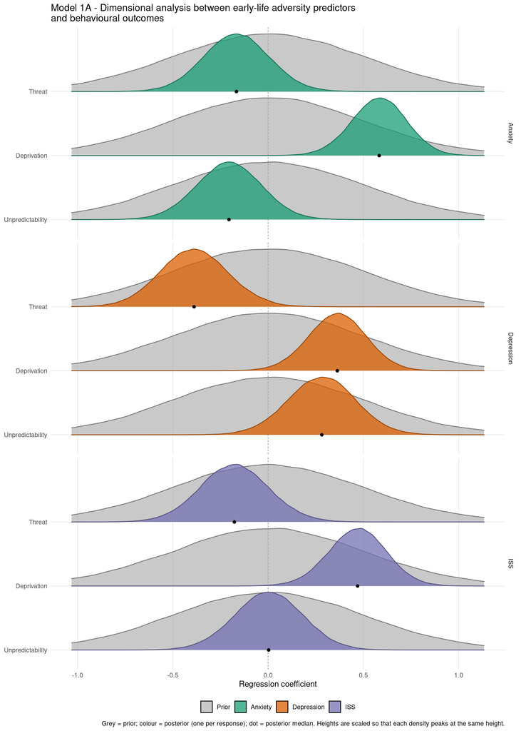

#### Prior and posterior predictive checks

##### Density overlays

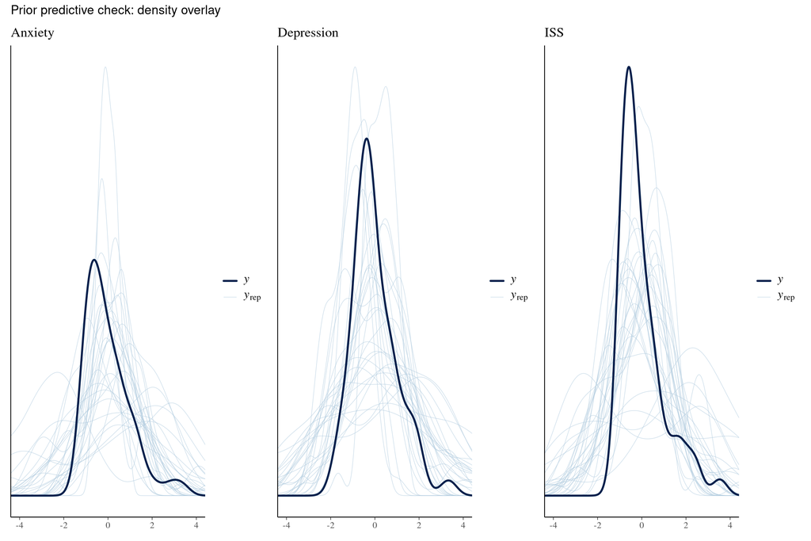

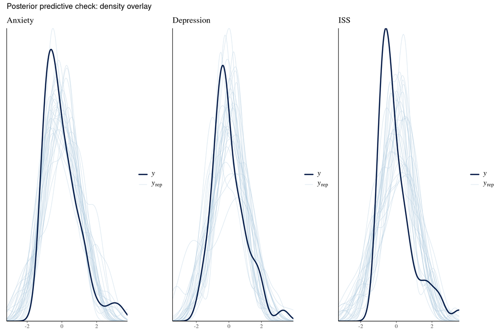

##### Minimum, Maximum and Skewness

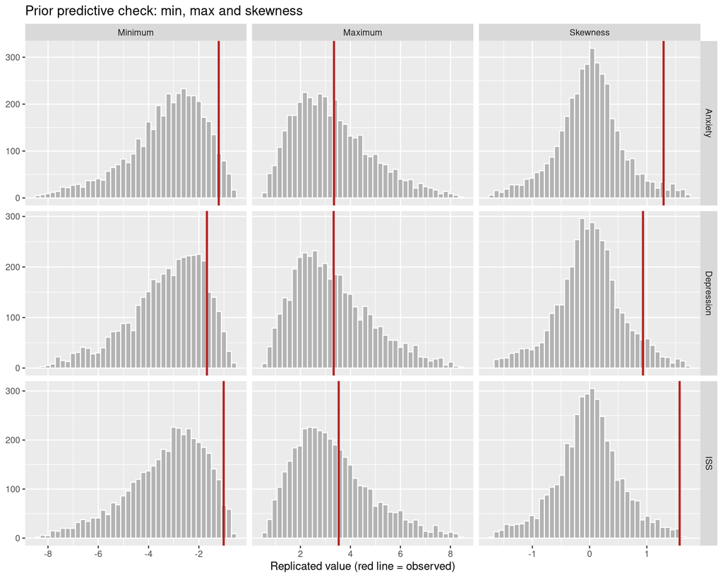

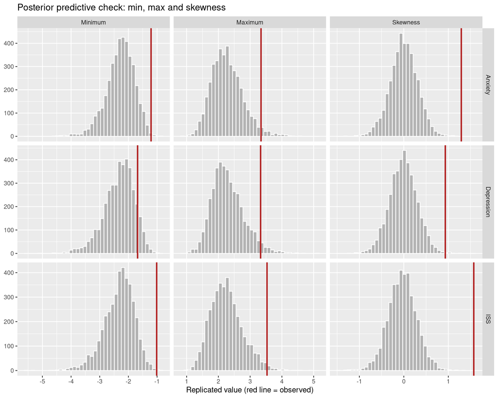

##### Pairwise correlation between dependent variables

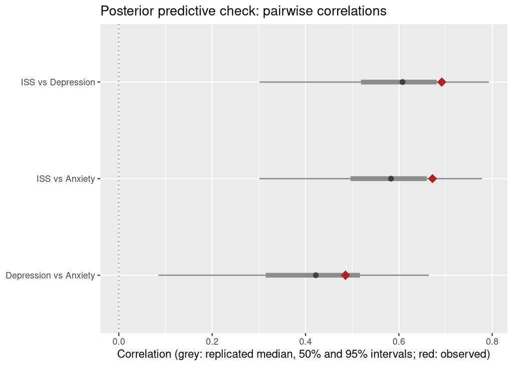

### Model 1B - Cumulative risk analysis between early-life adversity predictors and behavioural outcomes

| Parameter | Posterior Estimate | Posterior **95% CrI** | P(direction) | Convergence Rhat | Convergence Bulk ESS | Convergence Tail ESS |
| --- | --- | --- | --- | --- | --- | --- |
| Model 1B |  |  |  |  |  |  |
| Anxiety_Sex_2female | −0.22 | [−0.66, 0.23] | 0.839 | 1.001 | 4,324 | 4,684 |
| Anxiety_Sex_2male | 0.15 | [−0.29, 0.57] | 0.760 | 1.001 | 4,063 | 4,693 |
| Anxiety_CRS_2 | 0.14 | [−0.13, 0.40] | 0.851 | 1.001 | 5,092 | 5,461 |
| Depression_Sex_2female | 0.21 | [−0.21, 0.62] | 0.841 | 1.001 | 4,896 | 4,355 |
| Depression_Sex_2male | −0.15 | [−0.53, 0.24] | 0.787 | 1.001 | 4,935 | 4,430 |
| Depression_CRS_2 | 0.18 | [−0.08, 0.44] | 0.917 | 1.001 | 5,468 | 5,220 |
| ISS_Sex_2female | 0.02 | [−0.40, 0.44] | 0.544 | 1.002 | 4,578 | 4,450 |
| ISS_Sex_2male | 0.00 | [−0.38, 0.39] | 0.502 | 1.001 | 4,063 | 4,024 |
| ISS_CRS_2 | 0.21 | [−0.05, 0.47] | 0.947 | 1.001 | 4,700 | 5,345 |
| sd_Species_2__Anxiety_Intercept | 0.31 | [0.02, 0.97] |  | 1.005 | 2,137 | 2,055 |
| sd_Species_2__Depression_Intercept | 0.19 | [0.01, 0.74] |  | 1.002 | 2,755 | 2,855 |
| sd_Species_2__ISS_Intercept | 0.21 | [0.01, 0.77] |  | 1.003 | 2,535 | 2,526 |
| sigma_Anxiety | 0.95 | [0.79, 1.16] |  | 1.001 | 5,299 | 4,871 |
| sigma_Depression | 0.95 | [0.80, 1.17] |  | 1.001 | 6,283 | 5,288 |
| sigma_ISS | 0.95 | [0.80, 1.17] |  | 1.001 | 5,387 | 4,656 |
| rescor__Anxiety__Depression | 0.51 | [0.28, 0.68] | 1.000 | 1.002 | 5,274 | 5,262 |
| rescor__Anxiety__ISS | 0.63 | [0.43, 0.77] | 1.000 | 1.002 | 5,234 | 5,541 |
| rescor__Depression__ISS | 0.63 | [0.44, 0.77] | 1.000 | 1.002 | 6,260 | 5,436 |

Estimates are posterior medians or means pooled across imputed datasets; intervals are equal-tailed 95% CrIs.  
P(direction) = probability of direction.  
Convergence diagnostics are the worst values across imputations; shaded cells have Rhat > 1.01 or ESS < 400.

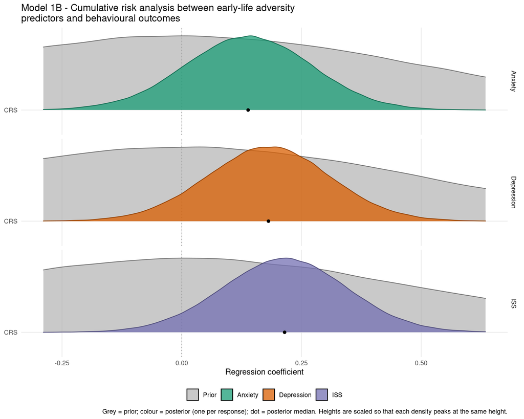

#### Prior and posterior predictive checks

##### Density overlays

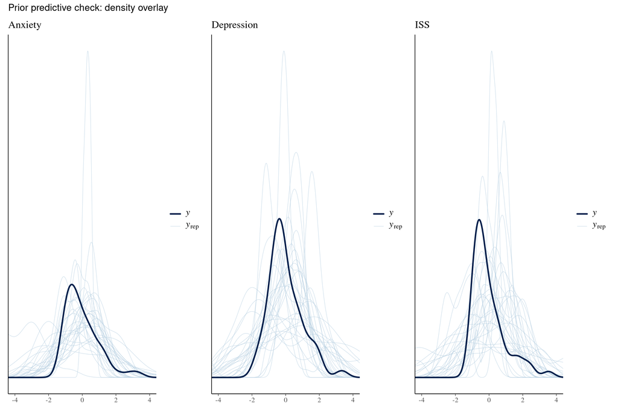

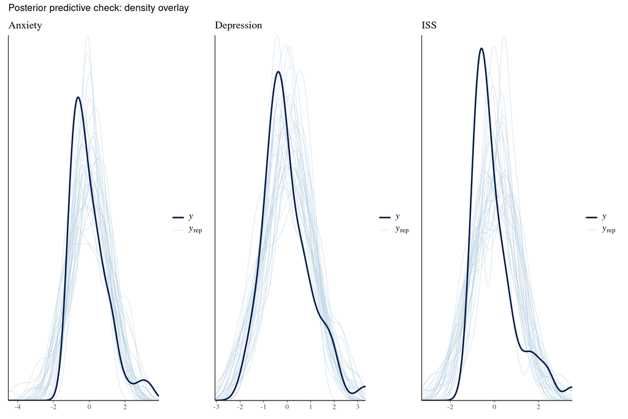

##### Minimum, Maximum and Skewness

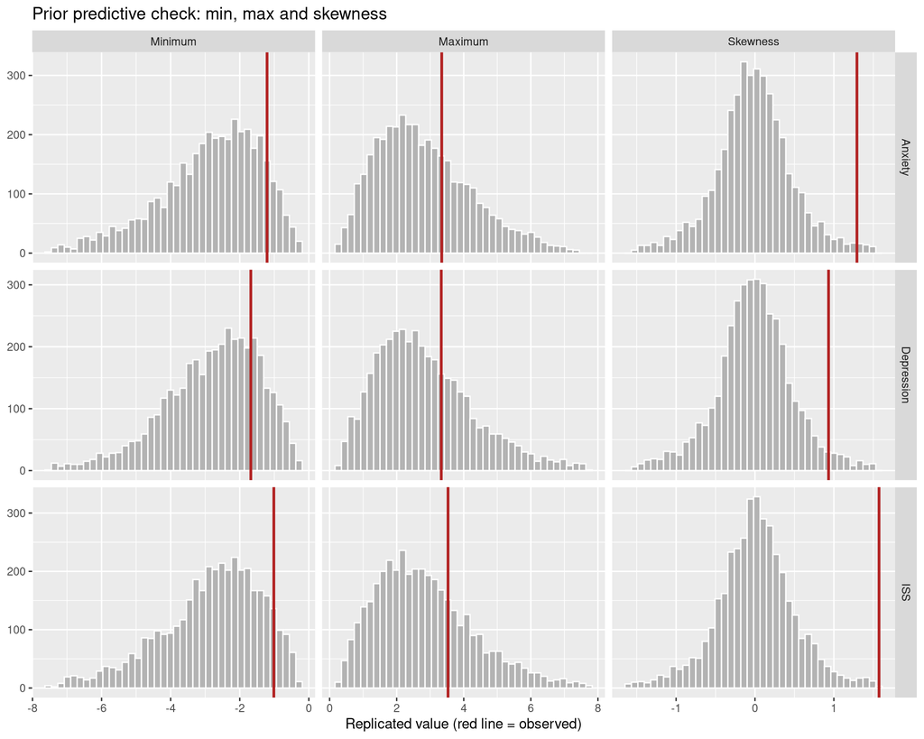

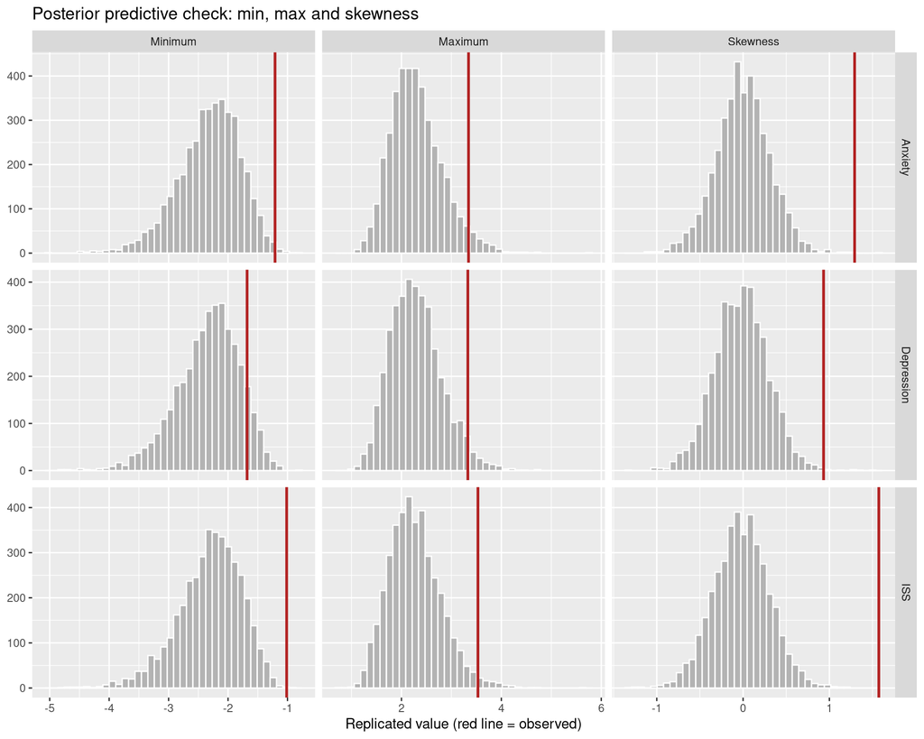

##### Pairwise correlation between dependent variables

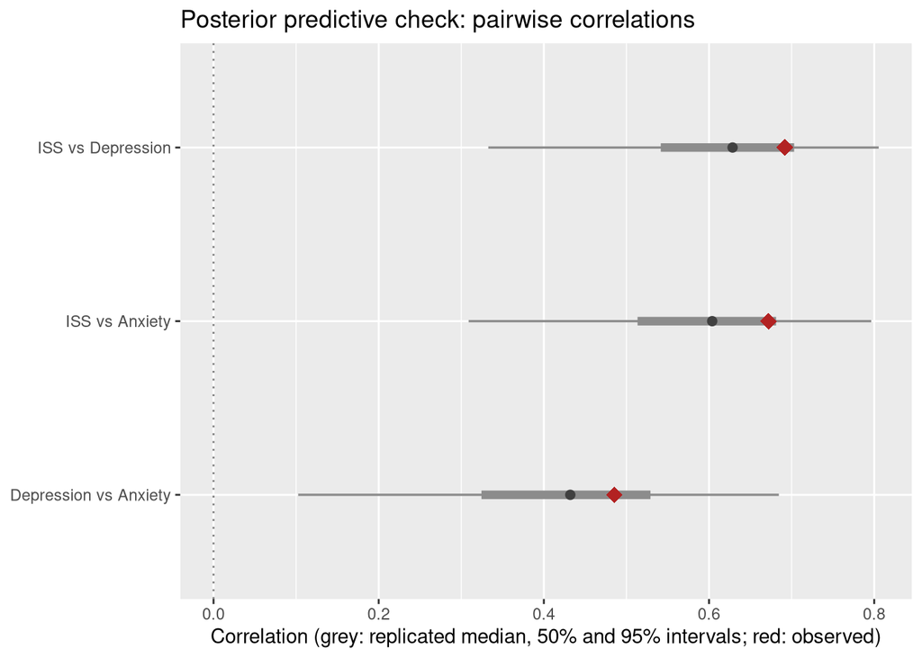

### Model 2A - Moderation effect of the estimated age at arrival to the centre for the dimensional approach

| Parameter | Posterior Estimate | Posterior **95% CrI** | P(direction) | Convergence Rhat | Convergence Bulk ESS | Convergence Tail ESS |
| --- | --- | --- | --- | --- | --- | --- |
| Model 2A |  |  |  |  |  |  |
| Anxiety_Sex_2female | −0.33 | [−0.75, 0.10] | 0.938 | 1.001 | 4,907 | 5,301 |
| Anxiety_Sex_2male | 0.26 | [−0.14, 0.64] | 0.907 | 1.002 | 4,990 | 4,978 |
| Anxiety_Threat | −0.19 | [−0.59, 0.21] | 0.822 | 1.001 | 4,872 | 4,794 |
| Anxiety_EstimatedAgeArrival | 0.03 | [−0.37, 0.44] | 0.561 | 1.001 | 5,010 | 4,664 |
| Anxiety_Deprivation | 0.53 | [0.10, 0.95] | 0.992 | 1.001 | 4,881 | 5,329 |
| Anxiety_Unpredictability | −0.30 | [−0.64, 0.04] | 0.960 | 1.002 | 5,310 | 5,050 |
| Anxiety_Threat:EstimatedAgeArrival | −0.27 | [−0.74, 0.21] | 0.868 | 1.001 | 5,628 | 5,211 |
| Anxiety_EstimatedAgeArrival:Deprivation | −0.18 | [−0.69, 0.34] | 0.749 | 1.001 | 4,538 | 4,743 |
| Anxiety_EstimatedAgeArrival:Unpredictability | 0.36 | [0.05, 0.67] | 0.989 | 1.001 | 5,033 | 5,166 |
| Depression_Sex_2female | 0.03 | [−0.42, 0.48] | 0.551 | 1.001 | 5,091 | 4,465 |
| Depression_Sex_2male | −0.10 | [−0.50, 0.33] | 0.685 | 1.001 | 4,621 | 4,379 |
| Depression_Threat | −0.28 | [−0.70, 0.14] | 0.906 | 1.002 | 5,085 | 5,124 |
| Depression_EstimatedAgeArrival | 0.22 | [−0.20, 0.65] | 0.851 | 1.001 | 5,163 | 5,469 |
| Depression_Deprivation | 0.31 | [−0.13, 0.75] | 0.916 | 1.001 | 4,954 | 5,186 |
| Depression_Unpredictability | 0.16 | [−0.20, 0.51] | 0.811 | 1.001 | 5,789 | 5,589 |
| Depression_Threat:EstimatedAgeArrival | −0.02 | [−0.52, 0.47] | 0.539 | 1.001 | 5,340 | 4,739 |
| Depression_EstimatedAgeArrival:Deprivation | 0.06 | [−0.46, 0.59] | 0.597 | 1.001 | 5,000 | 4,770 |
| Depression_EstimatedAgeArrival:Unpredictability | 0.10 | [−0.21, 0.42] | 0.738 | 1.001 | 5,077 | 5,381 |
| ISS_Sex_2female | −0.08 | [−0.54, 0.39] | 0.631 | 1.001 | 5,124 | 4,666 |
| ISS_Sex_2male | 0.05 | [−0.36, 0.47] | 0.606 | 1.001 | 4,955 | 5,026 |
| ISS_Threat | −0.18 | [−0.60, 0.25] | 0.802 | 1.001 | 5,000 | 5,187 |
| ISS_EstimatedAgeArrival | 0.09 | [−0.37, 0.56] | 0.646 | 1.001 | 4,857 | 5,335 |
| ISS_Deprivation | 0.43 | [−0.01, 0.87] | 0.973 | 1.001 | 4,785 | 4,996 |
| ISS_Unpredictability | −0.06 | [−0.43, 0.31] | 0.625 | 1.001 | 5,600 | 5,586 |
| ISS_Threat:EstimatedAgeArrival | −0.17 | [−0.67, 0.33] | 0.748 | 1.001 | 5,386 | 5,358 |
| ISS_EstimatedAgeArrival:Deprivation | −0.02 | [−0.61, 0.57] | 0.521 | 1.001 | 4,954 | 5,240 |
| ISS_EstimatedAgeArrival:Unpredictability | 0.18 | [−0.20, 0.54] | 0.814 | 1.002 | 5,220 | 4,507 |
| sd_Species_2__Anxiety_Intercept | 0.16 | [0.01, 0.69] |  | 1.001 | 2,844 | 3,221 |
| sd_Species_2__Depression_Intercept | 0.21 | [0.01, 0.80] |  | 1.003 | 2,538 | 2,522 |
| sd_Species_2__ISS_Intercept | 0.21 | [0.01, 0.77] |  | 1.003 | 2,778 | 3,331 |
| sigma_Anxiety | 0.79 | [0.65, 0.98] |  | 1.001 | 6,483 | 5,248 |
| sigma_Depression | 0.85 | [0.69, 1.05] |  | 1.001 | 5,867 | 5,240 |
| sigma_ISS | 0.88 | [0.72, 1.09] |  | 1.001 | 5,808 | 5,437 |
| rescor__Anxiety__Depression | 0.42 | [0.15, 0.62] | 0.998 | 1.001 | 5,758 | 5,017 |
| rescor__Anxiety__ISS | 0.51 | [0.26, 0.69] | 1.000 | 1.001 | 5,959 | 5,315 |
| rescor__Depression__ISS | 0.56 | [0.31, 0.73] | 1.000 | 1.001 | 6,190 | 5,607 |

Estimates are posterior medians or means pooled across imputed datasets; intervals are equal-tailed 95% CrIs.  
P(direction) = probability of direction.  
Convergence diagnostics are the worst values across imputations; shaded cells have Rhat > 1.01 or ESS < 400.

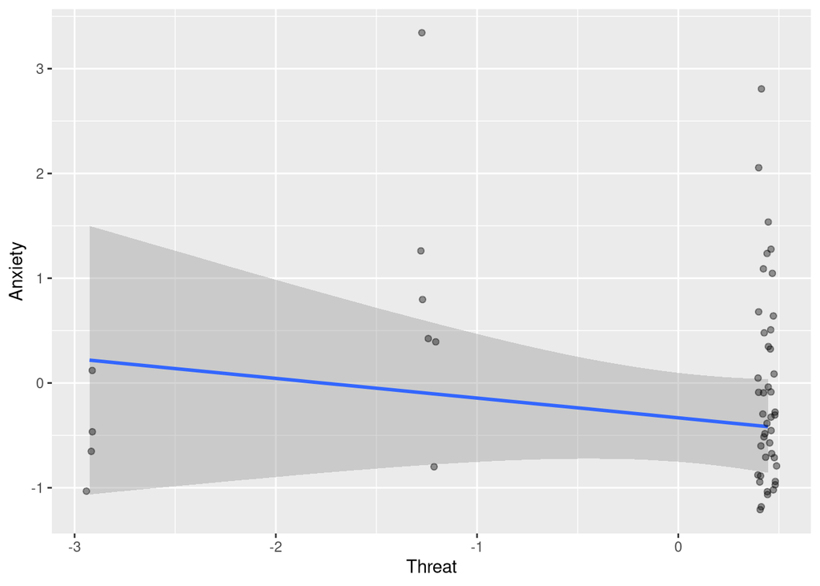

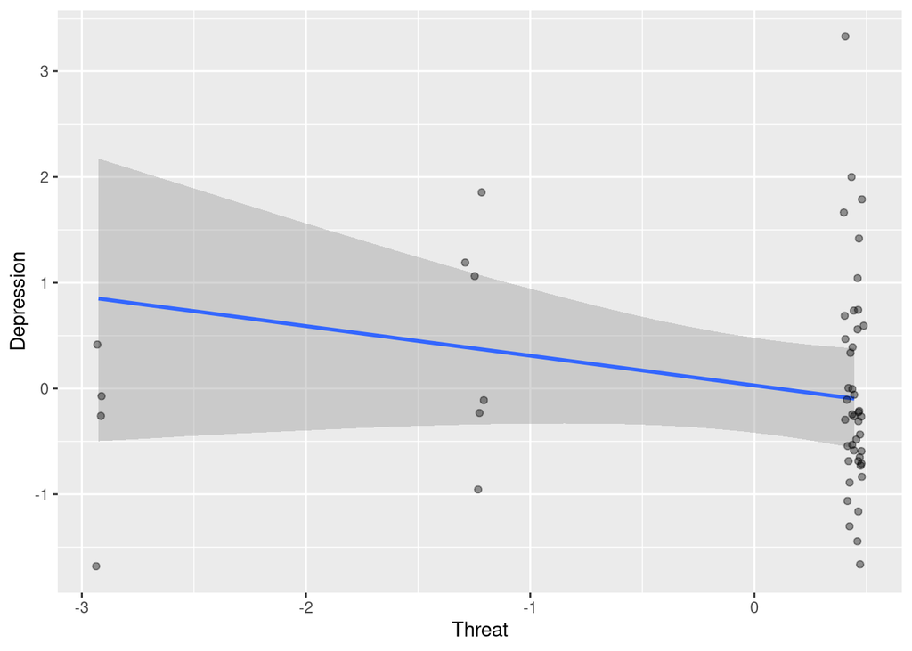

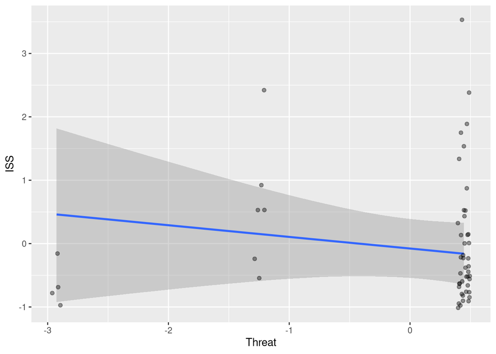